# Pruning & Rooting Phylogenetic Tree with ggTree for snail microbiome study

Daphne Garcia

2025-03-31

In this file, I inspected, pruned, and midpoint-rooted the phylogenetic tree created in `04A_Phylogenetic_Tree_Construction`

# Goals

1. Merge the unrooted tree to the `raw_preprocessed_phyloseq` object.
2. Visualize and inspect tree with ggtree
3. Evaluate long branches & prune ASVs, if needed
4. Root the tree with archaea or midpoint
1. Pre-processed phyloseq object from `data/03_PreProcessing/raw_preprocessed_physeq`.
2. The raw, unrooted ML tree from `data/04_PhylogeneticTree/ASVs_unrooted.tree`

## Timing, seed, load packages

```r
# What time did we start running this script?
start_time <- Sys.time()

# Any number can be chosen
set.seed(238428)

pacman::p_load(tidyverse, phyloseq, ggtree, phytools, tidytree, phylobase,
               install = FALSE)
```

# 1. Load Data files

```r
# Preprocessed phyloseq object
load("data/03_PreProcessing/raw_preprocessed_physeq.RData")

# Inspect the phyloseq object
raw_preprocessed_physeq
```

```
## phyloseq-class experiment-level object
## otu_table()   OTU Table:         [ 17817 taxa and 60 samples ]
## sample_data() Sample Data:       [ 60 samples by 38 sample variables ]
## tax_table()   Taxonomy Table:    [ 17817 taxa by 9 taxonomic ranks ]
```

```r
# Load in the tree!
unrooted_tree <- read.tree("data/04_PhylogeneticTree/ASVs_unrooted.tree")

# Take a look at the tree
unrooted_tree
```

```
##
## Phylogenetic tree with 17817 tips and 17815 internal nodes.
##
## Tip labels:
##   ASV_8391, ASV_16107, ASV_10507, ASV_15454, ASV_16288, ASV_7183, ...
## Node labels:
##   , 0.877, 0.843, 0.753, 0.884, 0.714, ...
##
## Unrooted; includes branch length(s).
```

```r
str(unrooted_tree)
```

```
## List of 5
##  $ edge       : int [1:35631, 1:2] 17818 17819 17820 17821 17822 17823 17824 17825 17826 17827 ...
##  $ edge.length: num [1:35631] 0.00517 0.00453 0.00262 0.00817 0.00413 ...
##  $ Nnode      : int 17815
##  $ node.label : chr [1:17815] "" "0.877" "0.843" "0.753" ...
##  $ tip.label  : chr [1:17817] "ASV_8391" "ASV_16107" "ASV_10507" "ASV_15454" ...
##  - attr(*, "class")= chr "phylo"
##  - attr(*, "order")= chr "cladewise"
```

# 2. Merge Unrooted Tree & `raw_preprocessed_physeq`

```r
# Intuition check
stopifnot(ntaxa(raw_preprocessed_physeq) == ntaxa(unrooted_tree))
# No news is good news!

# Merge the tree with the phyloseq object
unrooted_physeq <-
  merge_phyloseq(raw_preprocessed_physeq, unrooted_tree)

# Let's take a look!
unrooted_physeq
```

```
## phyloseq-class experiment-level object
## otu_table()   OTU Table:         [ 17817 taxa and 60 samples ]
## sample_data() Sample Data:       [ 60 samples by 38 sample variables ]
## tax_table()   Taxonomy Table:    [ 17817 taxa by 9 taxonomic ranks ]
## phy_tree()    Phylogenetic Tree: [ 17817 tips and 17815 internal nodes ]
```

# 3. Visualize and inspect tree with [ggtree]

## Kingdom Level Tree

Create and inspect the tree at the kingdom level (Bacteria, Archaea, Eukarya)

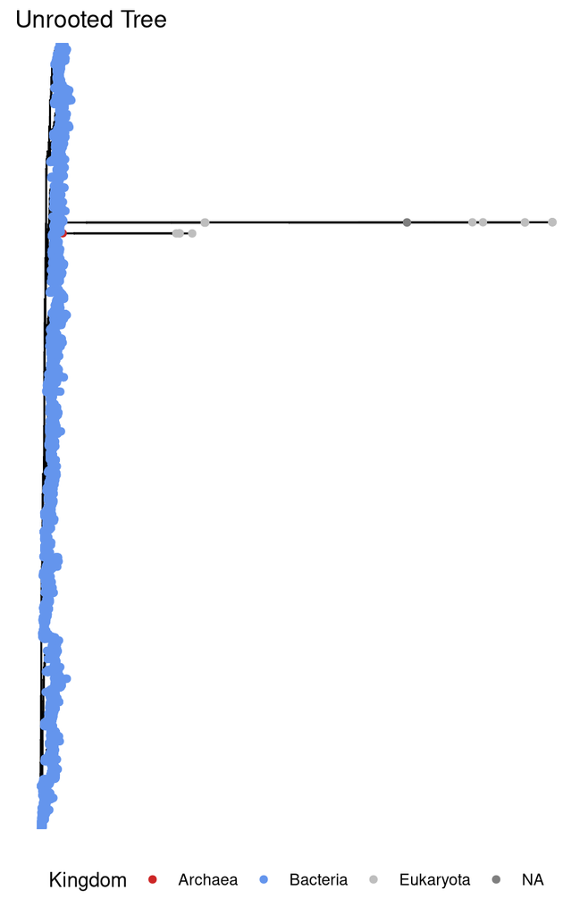

```r
# Make a basic tree with the domains
kingdom_tree <-
  ggtree(unrooted_physeq) +
  # color tips by kingdom
  geom_tippoint(mapping = aes(color = Kingdom)) +
  # add a title
  labs(title = "Unrooted Tree") +
  scale_color_manual(values = c("firebrick3", "cornflowerblue", "grey")) +
  # Move the legend to the bottom of the tree
  theme(legend.position = "bottom")

# Look at it
kingdom_tree
```

```r
# Check if tree is rooted
is.rooted(unrooted_tree) # should be TRUE
```

```
## [1] FALSE
```

# 4. Long Branches?

INTERPRETATION #1: Are there any suspect branches in the raw, unrooted tree? Or does your tree look “clean”? Why or why not?

There are two branches that are much longer than the rest. First, there is one node composed of mostly Eukaryota, and one visible NA. Another node has a few eukaryotes, and one archaea that seems to be closer, or more related to bacteria. Hopefully once I get rid of the eukaryotes, the archaea branch will be visibly more distant than the bacteria, but currently it seems as if the archaea branch is not really distant from bacteria.

## 4a. Evaluate Long Branches

### Kingdom Tree with Node Labels

Label the kingdom tree for more flexibility

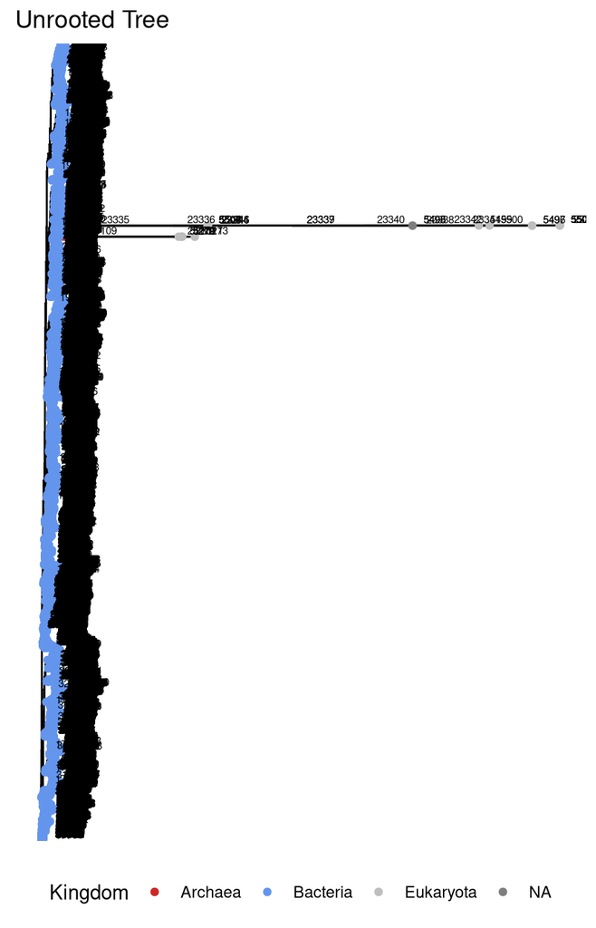

```r
kingdom_node_tree <-
  kingdom_tree +
  # Add the node label
  geom_text(aes(label=node), hjust= -0.5, vjust = -0.3, size = 2)

# Plot the tree
kingdom_node_tree
```

Looks like 23,335 and 23,109 are near the base of the two really long branches

### view specific branches: 23,335 and 23,109

Inspect 23,335 and 23,109, which appear to contain several eukaryotes

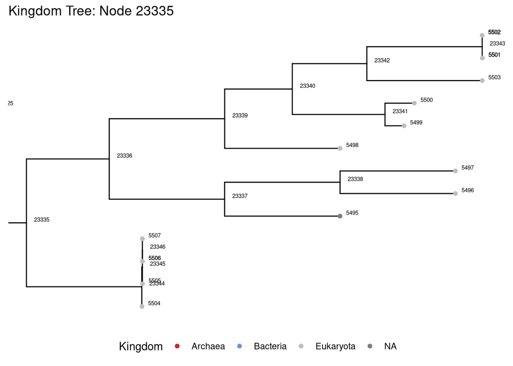

```r
# View a specific clade
# Zoom in on node that looks potentially suspicious
viewClade(kingdom_node_tree +
          labs(title = "Kingdom Tree: Node 23335"),
          node = 23335)
```

23335 is a whole branch of eukaryotes!!

### inspect

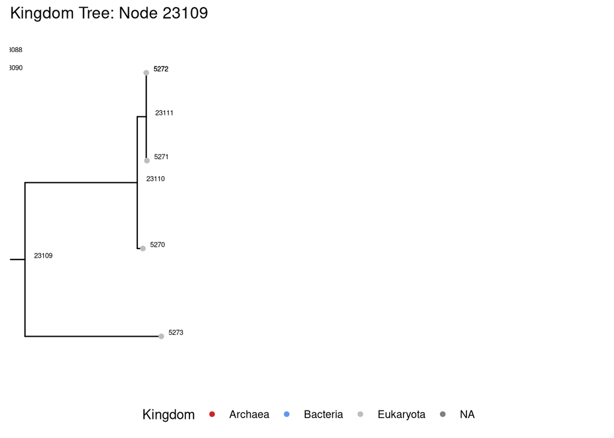

```r
# View a specific clade
# Zoom in on node that looks potentially suspicious
viewClade(kingdom_node_tree +
          labs(title = "Kingdom Tree: Node 23109"),
          node = 23109)
```

### inspect zoomed out branches of 23335 and 23109

Observing 23335 to identify last common ancestor of all eukarya, and common ancestor of all archaea

```r
#zoom out of 23335
tidytree::ancestor(unrooted_tree, 23335) # The input is the TREE, not phyloseq!!
```

```
##  [1] 23326 23325 23324 23112 23089 23088 22360 22322 22119 22118 22117 19060
## [13] 19059 19058 19036 19035 18891 18890 18889 18888 18887 18886 18885 18884
## [25] 18876 18874 17842 17826 17825 17824 17823 17822 17821 17820 17819 17818
```

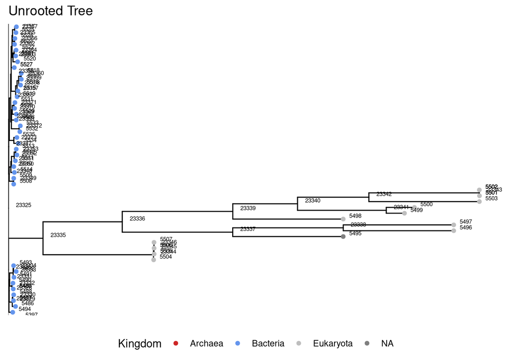

```r
  # looks like 23089 is MSA of 23335 and 23109!
  # Let's evaluate: 23324
  viewClade(kingdom_node_tree, 23325) # even more zoomed out
```

```r
  ## 23335 captures all of the eukaryotes in this branch

#zoom out of 23109
tidytree::ancestor(unrooted_tree, 23109) # The input is the TREE, not phyloseq!!
```

```
##  [1] 23090 23089 23088 22360 22322 22119 22118 22117 19060 19059 19058 19036
## [13] 19035 18891 18890 18889 18888 18887 18886 18885 18884 18876 18874 17842
## [25] 17826 17825 17824 17823 17822 17821 17820 17819 17818
```

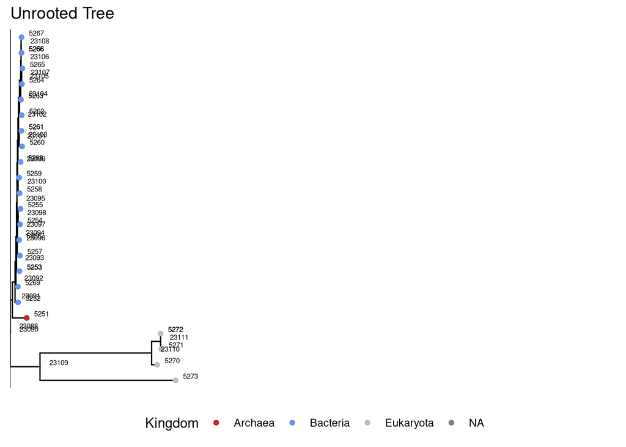

```r
  # looks like 23089 is MSA of 23335 and 23109!
  # Let's evaluate: 23324
  viewClade(kingdom_node_tree, 23090) # even more zoomed out
```

```r
  ## 23109 captures all of the eukaryotes in this branch BUT NOT ARCHAEA


#zoom out of 5251
tidytree::ancestor(unrooted_tree, 5251) # The input is the TREE, not phyloseq!!
```

```
##  [1] 23091 23090 23089 23088 22360 22322 22119 22118 22117 19060 19059 19058
## [13] 19036 19035 18891 18890 18889 18888 18887 18886 18885 18884 18876 18874
## [25] 17842 17826 17825 17824 17823 17822 17821 17820 17819 17818
```

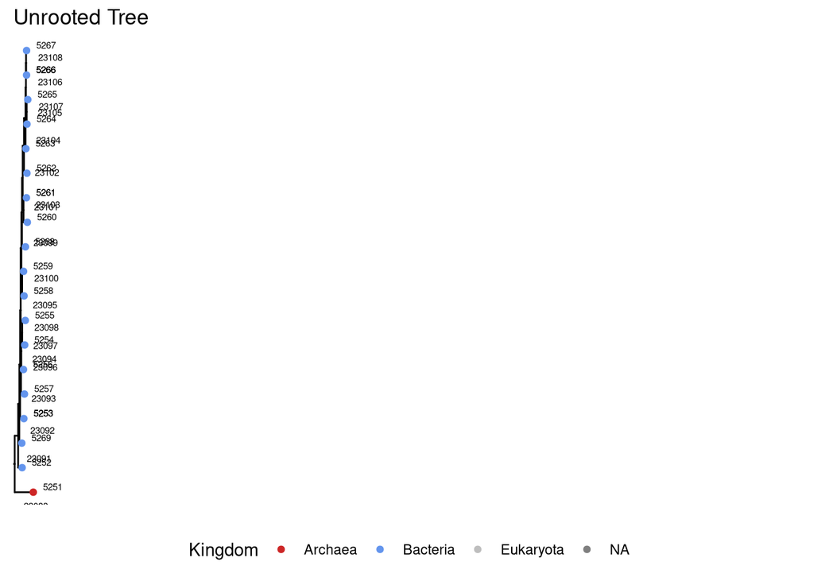

```r
  # looks like 23089 is MSA of 23335 and 23109!
  # Let's evaluate: 23324
  viewClade(kingdom_node_tree, 23091) # even more zoomed out
```

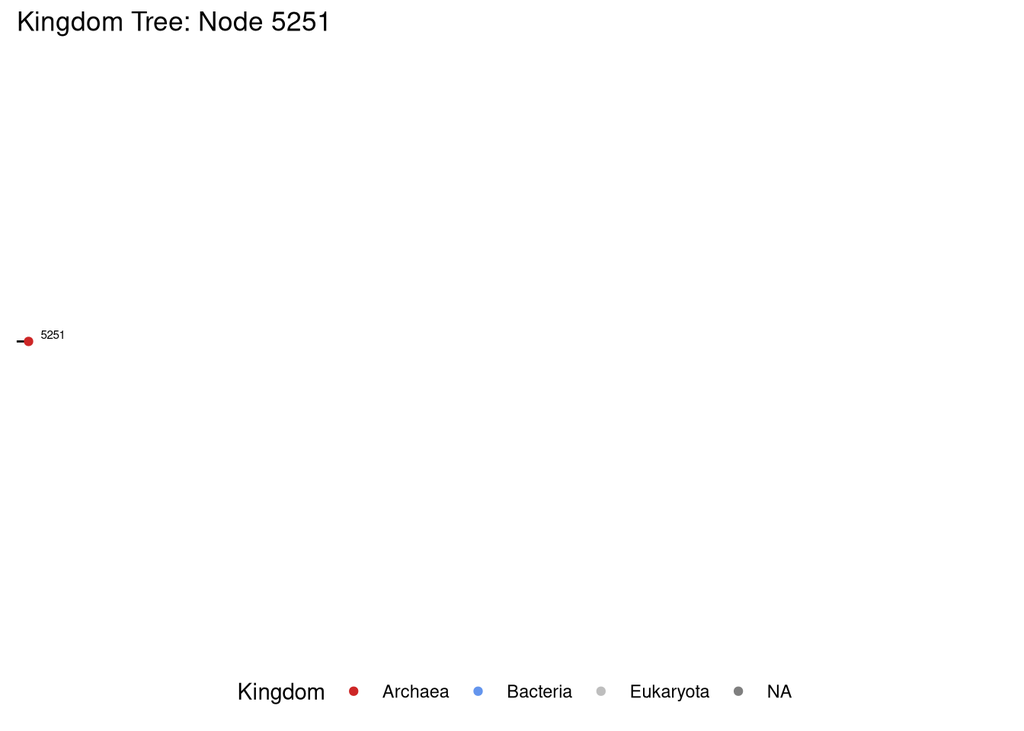

```r
  ## 5251 captures the one archaea of this branch

  # Zoom in on archaea node
viewClade(kingdom_node_tree +
          labs(title = "Kingdom Tree: Node 5251"),
          node = 5251)
```

### prepare nodes for 23335 and 23109

Identify if nodes 23335 and 23109 are most recent common ancestors

```r
# Or if there are two nodes that we can see we can find its MRCA
## create tibble of tree to identify offspring
tree_tib <- as_tibble(unrooted_physeq@phy_tree)

# Inspect
head(tree_tib)
```

```
## # A tibble: 6 × 4
##   parent  node branch.length label
##    <int> <int>         <dbl> <chr>
## 1  17827     1       0.0247  ASV_8391
## 2  17832     2       0.0381  ASV_16107
## 3  17834     3       0.0331  ASV_10507
## 4  17834     4       0.0264  ASV_15454
## 5  17833     5       0.0334  ASV_16288
## 6  17836     6       0.00532 ASV_7183
```

```r
str(tree_tib)
```

```
## tbl_tree [35,632 × 4] (S3: tbl_tree/tbl_df/tbl/data.frame)
##  $ parent       : int [1:35632] 17827 17832 17834 17834 17833 17836 17837 17837 17839 17839 ...
##  $ node         : int [1:35632] 1 2 3 4 5 6 7 8 9 10 ...
##  $ branch.length: num [1:35632] 0.0247 0.0381 0.0331 0.0264 0.0334 ...
##  $ label        : chr [1:35632] "ASV_8391" "ASV_16107" "ASV_10507" "ASV_15454" ...
```

```r
# lets look at the long branch
mrca_node_23335 <- tidytree::MRCA(unrooted_tree, .node1 = 23335)

# Inspect
mrca_node_23335
```

```
## [1] 23335
```

```r
## create dataframe to view ASVs and taxa info and to pull the ASVs
node_23335 <-
  offspring(tree_tib, mrca_node_23335, tiponly = TRUE) %>%
  as.data.frame() %>%
  pull(label)

# Inspect
node_23335
```

```
##  [1] "ASV_14718" "ASV_7318"  "ASV_10121" "ASV_6092"  "ASV_3884"  "ASV_9963"
##  [7] "ASV_1434"  "ASV_2060"  "ASV_9647"  "ASV_0496"  "ASV_1480"  "ASV_1009"
## [13] "ASV_5691"
```

### tree tibble for node 23109

create a tibble of 23109 for further inspection

```r
# Or if there are two nodes that we can see we can find its MRCA
## create tibble of tree to identify offspring
tree_tib <- as_tibble(unrooted_physeq@phy_tree)

# Inspect
head(tree_tib)
```

```
## # A tibble: 6 × 4
##   parent  node branch.length label
##    <int> <int>         <dbl> <chr>
## 1  17827     1       0.0247  ASV_8391
## 2  17832     2       0.0381  ASV_16107
## 3  17834     3       0.0331  ASV_10507
## 4  17834     4       0.0264  ASV_15454
## 5  17833     5       0.0334  ASV_16288
## 6  17836     6       0.00532 ASV_7183
```

```r
str(tree_tib)
```

```
## tbl_tree [35,632 × 4] (S3: tbl_tree/tbl_df/tbl/data.frame)
##  $ parent       : int [1:35632] 17827 17832 17834 17834 17833 17836 17837 17837 17839 17839 ...
##  $ node         : int [1:35632] 1 2 3 4 5 6 7 8 9 10 ...
##  $ branch.length: num [1:35632] 0.0247 0.0381 0.0331 0.0264 0.0334 ...
##  $ label        : chr [1:35632] "ASV_8391" "ASV_16107" "ASV_10507" "ASV_15454" ...
```

```r
# lets look at the long branch
mrca_node_23109 <- tidytree::MRCA(unrooted_tree, .node1 = 23109)

# Inspect
mrca_node_23109
```

```
## [1] 23109
```

```r
## create dataframe to view ASVs and taxa info and to pull the ASVs
node_23109 <-
  offspring(tree_tib, mrca_node_23109, tiponly = TRUE) %>%
  as.data.frame() %>%
  pull(label)

# Inspect
node_23109
```

```
## [1] "ASV_5895" "ASV_1669" "ASV_1853" "ASV_3796"
```

### Pull taxonomy for 23335 and 23109

Pull out the taxonomy information, including the ASV sequences for the two nodes of 23335 and 23109, to ensure that they are all eukaryotes and should be pruned

```r
# Now, let's pull out the taxonomy information, including the ASV sequence!
#### for 23335
node_23335_df <-
  unrooted_physeq %>%
  tax_table() %>%
  as.data.frame() %>%
  filter(ASV %in% node_23335)

# Take a look:
glimpse(node_23335_df)
```

```
## Rows: 13
## Columns: 9
## $ Kingdom <chr> NA, "Eukaryota", "Eukaryota", "Eukaryota", "Eukaryota", "Eukar…
## $ Phylum  <chr> NA, NA, NA, NA, NA, NA, NA, NA, NA, NA, NA, NA, NA
## $ Class   <chr> NA, NA, NA, NA, NA, NA, NA, NA, NA, NA, NA, NA, NA
## $ Order   <chr> NA, NA, NA, NA, NA, NA, NA, NA, NA, NA, NA, NA, NA
## $ Family  <chr> NA, NA, NA, NA, NA, NA, NA, NA, NA, NA, NA, NA, NA
## $ Genus   <chr> NA, NA, NA, NA, NA, NA, NA, NA, NA, NA, NA, NA, NA
## $ Species <chr> NA, NA, NA, NA, NA, NA, NA, NA, NA, NA, NA, NA, NA
## $ ASV     <chr> "ASV_14718", "ASV_7318", "ASV_10121", "ASV_6092", "ASV_3884", …
## $ ASVseqs <chr> "CCATCTCACATATTTCCCTAGGAGGCCAGCAGATTAGCTAACATCCTATGGCTGAAAGCTA…
```

```r
#### for 23109
node_23109_df <-
  unrooted_physeq %>%
  tax_table() %>%
  as.data.frame() %>%
  filter(ASV %in% node_23109)

# Take a look:
glimpse(node_23109_df)
```

```
## Rows: 4
## Columns: 9
## $ Kingdom <chr> "Eukaryota", "Eukaryota", "Eukaryota", "Eukaryota"
## $ Phylum  <chr> NA, NA, NA, NA
## $ Class   <chr> NA, NA, NA, NA
## $ Order   <chr> NA, NA, NA, NA
## $ Family  <chr> NA, NA, NA, NA
## $ Genus   <chr> NA, NA, NA, NA
## $ Species <chr> NA, NA, NA, NA
## $ ASV     <chr> "ASV_5895", "ASV_1669", "ASV_1853", "ASV_3796"
## $ ASVseqs <chr> "GCGCGCAACTTACCCACTCCCGGCTCGGGGAGGTAGTGACGAAAAATAACAATACGGAACT…
```

## Inspect ASV counts of 23335 and 23109

Inspect how many samples may have eukaryotic contamination

[output not shown]

### Inspecting the one archaea 5251

Inspect node 5251 to see if the labeled archaeon is a real ASV or a mislabeled ASV

```r
# Or if there are two nodes that we can see we can find its MRCA
## create tibble of tree to identify offspring
tree_tib <- as_tibble(unrooted_physeq@phy_tree)

# Inspect
head(tree_tib)
```

```
## # A tibble: 6 × 4
##   parent  node branch.length label
##    <int> <int>         <dbl> <chr>
## 1  17827     1       0.0247  ASV_8391
## 2  17832     2       0.0381  ASV_16107
## 3  17834     3       0.0331  ASV_10507
## 4  17834     4       0.0264  ASV_15454
## 5  17833     5       0.0334  ASV_16288
## 6  17836     6       0.00532 ASV_7183
```

```r
str(tree_tib)
```

```
## tbl_tree [35,632 × 4] (S3: tbl_tree/tbl_df/tbl/data.frame)
##  $ parent       : int [1:35632] 17827 17832 17834 17834 17833 17836 17837 17837 17839 17839 ...
##  $ node         : int [1:35632] 1 2 3 4 5 6 7 8 9 10 ...
##  $ branch.length: num [1:35632] 0.0247 0.0381 0.0331 0.0264 0.0334 ...
##  $ label        : chr [1:35632] "ASV_8391" "ASV_16107" "ASV_10507" "ASV_15454" ...
```

```r
# lets look at the long branch
mrca_node_5251 <- tidytree::MRCA(unrooted_tree, .node1 = 5251, )
ancestor(unrooted_tree, 5251)
```

```
##  [1] 23091 23090 23089 23088 22360 22322 22119 22118 22117 19060 19059 19058
## [13] 19036 19035 18891 18890 18889 18888 18887 18886 18885 18884 18876 18874
## [25] 17842 17826 17825 17824 17823 17822 17821 17820 17819 17818
```

```r
#create tibble to manipulate tree
node_test <- offspring(tree_tib, 23091, tiponly = TRUE) %>%
  as.data.frame()

# Inspect
mrca_node_5251
```

```
## [1] 5251
```

```r
## create dataframe to view ASVs and taxa info and to pull the ASVs
node_5251 <-
  offspring(tree_tib, 23091, tiponly = TRUE) %>%
  as.data.frame() %>%
  pull(label)

# Filtering for only archaea, since we only have one archaea in this node
node_5251_df <- as.data.frame(unrooted_physeq@tax_table) %>% filter(ASV %in% node_5251) %>%
  filter(Kingdom == "Archaea")

node_5251_df %>% pull(ASVseqs)
```

```
## [1] "TGGGGAATTTTGCGCAATGGGGGAAACCCTGACGCAGCAACGCCGCGTGGAGGATGAAGT…"
```

I blased and I’m getting a lot of uncultured archaeon hits, which is good, and the BLAST E valu e is prettly low (-133) BUT the Query value is not high enough (65%). We want it to be 70% or higher. And this ASV clusters really high to bacteria while we would expect it to be more divergent. We also blasted stuff on the same branch as the closest ancestor, and they appeared to be uncultured bacteria with 100% query cover. So this further convinces me that the archaea is not a real data point and should be pruned.